# **Predictive Modeling of Visa Application Outcomes**

### **Feature Engineering**

**Converting to 0-1 variables**

```python
_data_copy["case_status"].replace("Certified",1, inplace=True)
_data_copy["case_status"].replace("Denied",0, inplace=True)

_data_copy["has_job_experience"].replace("Y",1,  inplace=True)
_data_copy["has_job_experience"].replace("N",0,  inplace=True)

_data_copy["requires_job_training"].replace("Y",1,  inplace=True)
_data_copy["requires_job_training"].replace("N",0,  inplace=True)

_data_copy["full_time_position"].replace("Y",1,  inplace=True)
_data_copy["full_time_position"].replace("N",0,  inplace=True)
```

**Discretize variable considering the category based on the number of employees**

```python
_data_copy["no_of_employees"].nunique()
```

```
7105
```

```python
_bins_employees = [0, 10, 20, 50, 100, 500, 1000, 5000, 605000]
_labels_employees = ["Very_Small", "Small_1", "Small_2", "Small_3", "Medium", "Large_1", "Large_2", "Very_Large"]
# Applying bins to group by quantity.
_data_copy["no_of_employees_bins"] = pd.cut(
    _data_copy["no_of_employees"],
    bins=_bins_employees,
    labels=_labels_employees,
)
_data_copy["no_of_employees_bins"].head()
```

|  | no_of_employees_bins |
| --- | --- |
| 0 | Very_Large |
| 1 | Large_2 |
| 2 | Very_Large |
| 3 | Small_3 |
| 4 | Large_2 |

**dtype:** category

```python
_data_copy["no_of_employees_bins"].value_counts()
```

| no_of_employees_bins | count |
| --- | --- |
| Large_2 | 16602 |
| Large_1 | 3140 |
| Very_Large | 2637 |
| Medium | 2535 |
| Small_3 | 317 |
| Small_2 | 189 |
| Small_1 | 60 |
| Very_Small | 0 |

**dtype:** int64

#### Observations:

  Size Class Categories by Number of Employees in an Enterprise:

  Very small: 0–9, Small 1: 10–19, Small 2: 20–49, Small 3: 50–99, Medium: 100–499, Large 1: 500–999, Large 2: 1,000–4,999, Very large: 5,000 or more.

  *As an example.

  Georgi, P., Morrow, L., and Highfill, T. (November 19, 2021). "Updated and Expanded Small Business Statistics Wages, Employment, and Gross Output by Industry and Enterprise Size, 2012–2017". U.S. Bureau of Economic Analysis. https://apps.bea.gov/scb/issues/2021/11-november/1121-small-business.htm

**Standardize wage according to work modality and payment frequency**

```python
# New column to store "hours per year" considering if it is a full time job or not.
# 40 weekly hours * 52 (weeks in a year) = 2080 (full-time job)
# 35 weekly hours * 52 (weeks in a year) = 1820 (part-time job)
_data_copy['hours_per_year'] = _data_copy['full_time_position'].apply(lambda x: 2080 if x == 1 else 1820)

# Function to multiply each instance
def _to_yearly(_instance):
    if _instance['unit_of_wage'] == 'Hour':
        return _instance['hours_per_year']
    elif _instance['unit_of_wage'] == 'Week':
        return 52
    elif _instance['unit_of_wage'] == 'Month':
        return 12
    else:
        return 1  # Already yearly

_data_copy['wage_x_year'] = _data_copy.apply(_to_yearly, axis=1)
_data_copy['yearly_wage'] = _data_copy['prevailing_wage'] * _data_copy['wage_x_year']
_data_copy[['prevailing_wage', 'unit_of_wage', 'full_time_position', 'yearly_wage']].head()
```

|  | prevailing_wage | unit_of_wage | full_time_position | yearly_wage |
| --- | --- | --- | --- | --- |
| 0 | 592.2029 | Hour | 1 | 1231782.032 |
| 1 | 83425.6500 | Year | 1 | 83425.650 |
| 2 | 122996.8600 | Year | 1 | 122996.860 |
| 3 | 83434.0300 | Year | 1 | 83434.030 |
| 4 | 149907.3900 | Year | 1 | 149907.390 |

#### Observations:

According to the Wage and Hour Division of the U.S. Department of Labor, a full-time job consists of 40 hours per week, while a part-time job consists of 35 hours per week". (employment of H-1B workers).

- Having all wages in the same unit makes comparison easier.
- Better interpretation.
- Enhanced pattern detection.
- Better future visualizations.

Wage and Hour Division of the U.S. Department of Labor. (July 2009). What Constitutes a Full-Time Employee Under H-1B Visa Program? https://www.dol.gov/agencies/whd/fact-sheets/68-h1b-fulltime-employee

Herman, R. (n.d). "The Detailed Guide to Part Time H-1B Visa". Herman Legal Group. https://www.lawfirm4immigrants.com/part-time-h1b-visa/#:~:text=There%20is%20no%20rule%20as,per%20week%20for%20the%20employer

### **Data Preparation for modeling**

```python
_data_modeling  = pd.DataFrame()
_data_modeling['continent'] = _data_copy['continent']
_data_modeling['education_of_employee'] = _data_copy['education_of_employee']
_data_modeling['has_job_experience'] = _data_copy['has_job_experience']
_data_modeling['requires_job_training'] = _data_copy['requires_job_training']
_data_modeling['no_of_employees_bins'] = _data_copy['no_of_employees_bins']
_data_modeling['yr_of_estab'] = _data_copy['yr_of_estab']
_data_modeling['region_of_employment'] = _data_copy['region_of_employment']
_data_modeling['yearly_wage'] = _data_copy['yearly_wage']
_data_modeling['full_time_position'] = _data_copy['full_time_position']
_data_modeling['case_status'] = _data_copy['case_status']
_data_modeling.head()
```

|  | continent | education_of_employee | has_job_experience | requires_job_training | no_of_employees_bins | yr_of_estab | region_of_employment | yearly_wage | full_time_position | case_status |
| --- | --- | --- | --- | --- | --- | --- | --- | --- | --- | --- |
| 0 | Asia | High School | 0 | 0 | Very_Large | 2007 | West | 1231782.032 | 1 | 0 |
| 1 | Asia | Master's | 1 | 0 | Large_2 | 2002 | Northeast | 83425.650 | 1 | 1 |
| 2 | Asia | Bachelor's | 0 | 1 | Very_Large | 2008 | West | 122996.860 | 1 | 0 |
| 3 | Asia | Bachelor's | 0 | 0 | Small_3 | 1897 | West | 83434.030 | 1 | 0 |
| 4 | Africa | Master's | 1 | 0 | Large_2 | 2005 | South | 149907.390 | 1 | 1 |

**Data splitting**

```python
X = _data_modeling.drop(["case_status"], axis=1)
y = _data_modeling["case_status"]
```

**Original data**

```python
# Splitting data into training, validation and test set:
X_temp, X_test, y_temp, y_test = train_test_split(
    X, y, test_size=0.2, random_state=1, stratify=y
)

# Split the temporary set into train and validation
X_train, X_val, y_train, y_val = train_test_split(
    X_temp, y_temp, test_size=0.25, random_state=1, stratify=y_temp
)
print(X_train.shape, X_val.shape, X_test.shape)
```

```
(15288, 9) (5096, 9) (5096, 9)
```

```python
# Creating dummy variables
X_train = pd.get_dummies(X_train, columns=X_train.select_dtypes(include=["object", "category"]).columns.tolist(), drop_first=True)
X_train = X_train.astype(float)

X_val = pd.get_dummies(X_val, columns=X_val.select_dtypes(include=["object", "category"]).columns.tolist(), drop_first=True)
X_val = X_val.astype(float)

X_test = pd.get_dummies(X_test, columns=X_test.select_dtypes(include=["object", "category"]).columns.tolist(), drop_first=True)
X_test = X_test.astype(float)
```

```python
print("Shape of training: ", X_train.shape)
print("Shape of validation: ", X_val.shape)
print("Shape of test: ", X_test.shape)
print("Percentage of classes in training:")
print(y_train.value_counts(normalize=True))
print("Percentage of classes in validation:")
print(y_val.value_counts(normalize=True))
print("Percentage of classes in test:")
print(y_test.value_counts(normalize=True))
```

```
Shape of training:  (15288, 24)
Shape of validation:  (5096, 24)
Shape of test:  (5096, 24)
Percentage of classes in training:
case_status
1    0.667844
0    0.332156
Name: proportion, dtype: float64
Percentage of classes in validation:
case_status
1    0.667975
0    0.332025
Name: proportion, dtype: float64
Percentage of classes in test:
case_status
1    0.667975
0    0.332025
Name: proportion, dtype: float64
```

#### Observations

- Three sets of data were created: training set (consisting of 15,288 instances), validation set (containing 5,096 instances) and testing set (also containing 5,096 instances).
- Stratify technique was employed to preserve the proportional representation of each class within the respective sets.
- Dummy variables were created independently for each set to avoid data leakage.

**Sampling**

```python
# Class balance.

print("Target value ratio in y")
print(y.value_counts(1))
print("*" * 40)
print("Target value ratio in y_train")
print(y_train.value_counts(1))
print("*" * 40)
print("Target value ratio in y_val")
print(y_val.value_counts(1))
print("*" * 40)
print("Target value ratio in y_test")
print(y_test.value_counts(1))
print("*" * 40)
```

```
Target value ratio in y
case_status
1    0.667896
0    0.332104
Name: proportion, dtype: float64
Target value ratio in y_train
case_status
1    0.667844
0    0.332156
Name: proportion, dtype: float64
Target value ratio in y_val
case_status
1    0.667975
0    0.332025
Name: proportion, dtype: float64
Target value ratio in y_test
case_status
1    0.667975
0    0.332025
Name: proportion, dtype: float64
```

**Oversampled data**

#### **Fit Synthetic Minority Oversampling Technique - SMOTE - on train data**

**SMOTE parameters:**

- **sampling_strategy** = 1. Meaning: ratio of minority to majority class after resampling.
- **k_neighbors** = 5. Meaning: how many nearest neighbors are used to generate synthetic samples. It picks one randomly and creates a new synthetic point between them.
- **random_state** = 1.
- **x_train_over_sampled, y_train_over_sampled** = fit_resample (x_train, y_train)

```python
print("Before Oversampling, counts of label 'Certified': {}".format(sum(y_train == 1)))
print("Before Oversampling, counts of label 'Denied': {} \n".format(sum(y_train == 0)))

print("After Oversampling, counts of label 'Certified': {}".format(sum(y_train_over == 1)))
print("After Oversampling, counts of label 'Denied': {} \n".format(sum(y_train_over == 0)))

print("After Oversampling, the shape of train_X: {}".format(X_train_over.shape))
print("After Oversampling, the shape of train_y: {} \n".format(y_train_over.shape))
```

```
Before Oversampling, counts of label 'Certified': 10210
Before Oversampling, counts of label 'Denied': 5078

After Oversampling, counts of label 'Certified': 10210
After Oversampling, counts of label 'Denied': 10210

After Oversampling, the shape of train_X: (20420, 24)
After Oversampling, the shape of train_y: (20420,)
```

**Undersampled data**

#### **RandomUnderSampler - on train data**

- random_state = 1.
- x_train_under_sampled, y_train_under_sampled = fit_resample (x_train, y_train)

```python
print("Before Under Sampling, counts of label 'Certified': {}".format(sum(y_train == 1)))
print("Before Under Sampling, counts of label 'Denied': {} \n".format(sum(y_train == 0)))

print("After Under Sampling, counts of label 'Certified': {}".format(sum(y_train_un == 1)))
print("After Under Sampling, counts of label 'Denied': {} \n".format(sum(y_train_un == 0)))

print("After Under Sampling, the shape of train_X: {}".format(X_train_un.shape))
print("After Under Sampling, the shape of train_y: {} \n".format(y_train_un.shape))
```

```
Before Under Sampling, counts of label 'Certified': 10210
Before Under Sampling, counts of label 'Denied': 5078

After Under Sampling, counts of label 'Certified': 5078
After Under Sampling, counts of label 'Denied': 5078

After Under Sampling, the shape of train_X: (10156, 24)
After Under Sampling, the shape of train_y: (10156,)
```

## **Model Building**

### **Model Evaluation Criterion**

Considering the following objectives:

- Shortlisting the candidates having higher chances of VISA approval.
- Facilitate the process of visa approvals.
- Understand which attributes increase the likelihood of approval or rejection (both "certified" and "denied").

This case study requires identifying both false negatives (actual positive, predicted negative) being minimized = RECALL and, false positives (actual negative, predicted positive) being minimized = PRECISION.

**Conclusion**: the primary objective of this case study is to minimize both the number of applicants with a high probability of visa approval being predicted as "denied", and to minimize the number of applicants with a low probability of being approved being predicted as good candidates ("certified"). **Therefore, F1-Score will be the principal metric.** due to its balanced assessment of these two scenarios.

### **Model building with original data**

```python
# Bagging
_models.append(("DecisionTree", DecisionTreeClassifier(random_state=1, class_weight='balanced')))
_models.append(("Bagging", BaggingClassifier(estimator=DecisionTreeClassifier(random_state=1, class_weight='balanced'), random_state=1)))
_models.append(("RandomForest", RandomForestClassifier(random_state=1, class_weight='balanced')))

# Boosting
_models.append(("ADABoost", AdaBoostClassifier(random_state=1)))
_models.append(("GradientBoost", GradientBoostingClassifier(random_state=1)))
_models.append(("XGBoost", XGBClassifier(random_state=1, eval_metric="logloss")))
```

### **For each model**

- **Scorer**: metrics.f1_score
- **Fit**(x_train, y_train)
- **StratifiedKFold**: 5 splits, shuffle true, random state 1
- **cross_val_score**: model + X + y + scoring + cv (stratifiedKFold)

```python
_perf_training_original
```

|  | Model | F1 score |
| --- | --- | --- |
| 0 | DecisionTree | 1.000000 |
| 1 | Bagging | 0.987437 |
| 2 | RandomForest | 1.000000 |
| 3 | ADABoost | 0.818785 |
| 4 | GradientBoost | 0.824199 |
| 5 | XGBoost | 0.879055 |

```python
_perf_training_cv_original
```

|  | Model | KFold_CV_result | Accuracy |
| --- | --- | --- | --- |
| 0 | DecisionTree | 0.740615 | Accuracy: 74.062% (0.727%) |
| 1 | Bagging | 0.767038 | Accuracy: 76.704% (0.625%) |
| 2 | RandomForest | 0.790468 | Accuracy: 79.047% (0.556%) |
| 3 | ADABoost | 0.817977 | Accuracy: 81.798% (0.364%) |
| 4 | GradientBoost | 0.818003 | Accuracy: 81.800% (0.198%) |
| 5 | XGBoost | 0.807483 | Accuracy: 80.748% (0.297%) |

```python
_perf_validation_original
```

|  | Model | F1 score |
| --- | --- | --- |
| 0 | DecisionTree | 0.737584 |
| 1 | Bagging | 0.769956 |
| 2 | RandomForest | 0.791009 |
| 3 | ADABoost | 0.815378 |
| 4 | GradientBoost | 0.821876 |
| 5 | XGBoost | 0.809245 |

```python
print("\nTraining and Validation Performance Difference: ORIGINAL DATA \n")

_df_differences_original = pd.merge(_perf_training_original, _perf_validation_original, on="Model", suffixes=("_train", "_val"))
_df_differences_original["Difference"] = _df_differences_original["F1 score_train"] - _df_differences_original["F1 score_val"]

df_resultado = _df_differences_original[["Model", "Difference"]]
df_resultado
```

```
Training and Validation Performance Difference: ORIGINAL DATA
```

|  | Model | Difference |
| --- | --- | --- |
| 0 | DecisionTree | 0.262416 |
| 1 | Bagging | 0.217482 |
| 2 | RandomForest | 0.208991 |
| 3 | ADABoost | 0.003407 |
| 4 | GradientBoost | 0.002323 |
| 5 | XGBoost | 0.069810 |

#### Observations

Six different models were developed based on the original dataset to evaluate multiple ensemble techniques. Three of these models implemented bagging methods; utilizing three different classifiers: "Decision Tree", "Bagging with decision trees as base estimators", and "Random Forest". The remaining three models, implemented boosting methods to evaluate the classifiers: "AdaBoost", "GradientBoost", and "XGBoost". **All models were implemented with their default parameter settings, without hyperparameter tuning**.

In this initial phase of model development, the primary focus will be on the F1-Score as the principal performance metric of the case study, along with the cross-validation score for each model.

The cross-validation score represents the average accuracy of the model across multiple data partitions, evaluating its overall performance in predicting both positive and negative instances.

For this analysis, the 'StratifiedKFold' function was used to preserve the ratio of different classes within each fold of the cross-validation process, considering 5 folds.

After identifying the optimal models, hyperparameter optimization will be performed, and a detailed analysis of all metrics will be conducted, confusion matrices will be generated, and a detailed comparative study of each model's performance will be undertaken.

**Results of the models on the original dataset (without sampling or hyperparameter tuning)**:

- Decision Tree, Bagging, and Random Forest models got overfitted.
- **The boosting models: AdaBoost, GradientBoost, and XGBoost, demonstrate good generalization.**
- **GradientBoost is identified as the best-performing model, with an F1-Score of 0.8242 on the training set and, 0.8218 on the validation set.**
- Decision tree model: mean accuracy is 74% with a standard deviation of 0.73%. Such a lower standard deviation indicates that the model's accuracy is stable across different splits of the data; however, its mean accuracy is not appropriate. The model is consistently but not good enough.
- AdaBoost model: mean accuracy is 81.8% with a standard deviation of 0.364%. The accuracy on any unseen data will lie between 81.09 and 82.51 with a confidence of 95% (avg +- 1.96 * std)

### **Model Building with oversampled data**

```python
# Bagging
_models.append(("DecisionTree", DecisionTreeClassifier(random_state=1, class_weight='balanced')))
_models.append(("Bagging", BaggingClassifier(estimator=DecisionTreeClassifier(random_state=1, class_weight='balanced'), random_state=1)))
_models.append(("RandomForest", RandomForestClassifier(random_state=1, class_weight='balanced')))

# Boosting
_models.append(("ADABoost", AdaBoostClassifier(random_state=1)))
_models.append(("GradientBoost", GradientBoostingClassifier(random_state=1)))
_models.append(("XGBoost", XGBClassifier(random_state=1, eval_metric="logloss")))
```

### **For each model**

- **Scorer**: metrics.f1_score
- **Fit**(x_train_overSampled, y_train_overSampled)
- **StratifiedKFold**: 5 splits, shuffle true, random state 1
- **cross_val_score**: model + X + y + scoring + cv (stratifiedKFold)

```python
_perf_training_over
```

|  | Model | F1 score |
| --- | --- | --- |
| 0 | DecisionTree | 1.000000 |
| 1 | Bagging | 0.985031 |
| 2 | RandomForest | 0.999951 |
| 3 | ADABoost | 0.805449 |
| 4 | GradientBoost | 0.818541 |
| 5 | XGBoost | 0.875105 |

```python
_perf_training_cv_over
```

|  | Model | KFold_CV_result | Accuracy |
| --- | --- | --- | --- |
| 0 | DecisionTree | 0.738612 | Accuracy: 73.861% (0.409%) |
| 1 | Bagging | 0.766042 | Accuracy: 76.604% (0.533%) |
| 2 | RandomForest | 0.788214 | Accuracy: 78.821% (0.274%) |
| 3 | ADABoost | 0.807054 | Accuracy: 80.705% (0.716%) |
| 4 | GradientBoost | 0.813964 | Accuracy: 81.396% (0.485%) |
| 5 | XGBoost | 0.807149 | Accuracy: 80.715% (0.536%) |

```python
_perf_validation_over
```

|  | Model | F1 score |
| --- | --- | --- |
| 0 | DecisionTree | 0.742314 |
| 1 | Bagging | 0.769824 |
| 2 | RandomForest | 0.787219 |
| 3 | ADABoost | 0.809818 |
| 4 | GradientBoost | 0.817290 |
| 5 | XGBoost | 0.812369 |

```python
print("\nTraining and Validation Performance Difference: OVERSAMPLED DATA \n")

_df_differences_over = pd.merge(_perf_training_over, _perf_validation_over, on="Model", suffixes=("_train", "_val"))
_df_differences_over["Difference"] = _df_differences_over["F1 score_train"] - _df_differences_over["F1 score_val"]

df_resultado_over = _df_differences_over[["Model", "Difference"]]
df_resultado_over
```

```
Training and Validation Performance Difference: OVERSAMPLED DATA
```

|  | Model | Difference |
| --- | --- | --- |
| 0 | DecisionTree | 0.257686 |
| 1 | Bagging | 0.215207 |
| 2 | RandomForest | 0.212732 |
| 3 | ADABoost | -0.004369 |
| 4 | GradientBoost | 0.001251 |
| 5 | XGBoost | 0.062736 |

#### Observations:

Same 6 models were executed, but this time on the oversampled data.

- Similarly, the bagging models exhibited overfitting.
- The boosting models demonstrated a good performance and generalization.
- Again, 'GradientBoost' is identified as the best-performing model. It demonstrates good generalization and a smaller difference in F1-Score between the training and validation sets, with a difference of 0.001251 (F1-Score in training set 0.8185 and 0.817290 in validation set).
- GradientBoost mean accuracy is 81.40% with a standard deviation of 0.485%. The accuracy on any unseen data will lie between 80,45 and 82,35 with a confidence of 95% (avg +- 1.96 * std).

### **Model building with undersampled data**

```python
# Bagging
_models.append(("DecisionTree", DecisionTreeClassifier(random_state=1, class_weight='balanced')))
_models.append(("Bagging", BaggingClassifier(estimator=DecisionTreeClassifier(random_state=1, class_weight='balanced'), random_state=1)))
_models.append(("RandomForest", RandomForestClassifier(random_state=1, class_weight='balanced')))

# Boosting
_models.append(("ADABoost", AdaBoostClassifier(random_state=1)))
_models.append(("GradientBoost", GradientBoostingClassifier(random_state=1)))
_models.append(("XGBoost", XGBClassifier(random_state=1, eval_metric="logloss")))
```

### **For each model**

- **Scorer**: metrics.f1_score
- **Fit**(x_train_underSampled, y_train_underSampled)
- **StratifiedKFold**: 5 splits, shuffle true, random state 1
- **cross_val_score**: model + X + y + scoring + cv (stratifiedKFold)

```python
_perf_training_under
```

|  | Model | F1 score |
| --- | --- | --- |
| 0 | DecisionTree | 1.000000 |
| 1 | Bagging | 0.976842 |
| 2 | RandomForest | 1.000000 |
| 3 | ADABoost | 0.693526 |
| 4 | GradientBoost | 0.725268 |
| 5 | XGBoost | 0.841019 |

```python
_perf_training_cv_under
```

|  | Model | KFold_CV_result | Accuracy |
| --- | --- | --- | --- |
| 0 | DecisionTree | 0.615984 | Accuracy: 61.598% (0.969%) |
| 1 | Bagging | 0.635071 | Accuracy: 63.507% (1.302%) |
| 2 | RandomForest | 0.668552 | Accuracy: 66.855% (0.997%) |
| 3 | ADABoost | 0.695860 | Accuracy: 69.586% (1.700%) |
| 4 | GradientBoost | 0.710283 | Accuracy: 71.028% (1.672%) |
| 5 | XGBoost | 0.684883 | Accuracy: 68.488% (1.399%) |

```python
_perf_validation_under
```

|  | Model | F1 score |
| --- | --- | --- |
| 0 | DecisionTree | 0.696950 |
| 1 | Bagging | 0.698674 |
| 2 | RandomForest | 0.725880 |
| 3 | ADABoost | 0.756628 |
| 4 | GradientBoost | 0.775612 |
| 5 | XGBoost | 0.743012 |

```python
print("\nTraining and Validation Performance Difference: UNDERSAMPLED DATA \n")

_df_differences_under = pd.merge(_perf_training_under, _perf_validation_under, on="Model", suffixes=("_train", "_val"))
_df_differences_under["Difference"] = _df_differences_under["F1 score_train"] - _df_differences_under["F1 score_val"]

df_resultado_over = _df_differences_over[["Model", "Difference"]]
df_resultado_over
```

```
Training and Validation Performance Difference: UNDERSAMPLED DATA
```

|  | Model | Difference |
| --- | --- | --- |
| 0 | DecisionTree | 0.257686 |
| 1 | Bagging | 0.215207 |
| 2 | RandomForest | 0.212732 |
| 3 | ADABoost | -0.004369 |
| 4 | GradientBoost | 0.001251 |
| 5 | XGBoost | 0.062736 |

#### Observations:

Same six models were executed, but this time on the undersampled data.

## **Hyperparameter Tuning**

### **Tuning AdaBoost using oversampled data**

```python
_ada = AdaBoostClassifier(random_state=1)

# Hyperparameters to consider
param_grid = {
    "n_estimators": np.arange(10, 100, 10),
    "learning_rate": [0.01, 0.05, 0.1, 0.2, 1, 1.5],
    "estimator": [
        DecisionTreeClassifier(random_state=1)
    ],
    "estimator__criterion": ["gini", "entropy"],
    "estimator__max_depth": [1, 2, 5, 8, 10, 12, 15],
    "estimator__min_samples_split": [2, 5, 10, 15]
}

# Type of scoring
scorer = metrics.make_scorer(metrics.f1_score)

_ada_randomized_cv = RandomizedSearchCV(estimator=_ada, param_distributions=param_grid, n_jobs = -1, n_iter=25, scoring=scorer, cv=5, random_state=1)

_ada_randomized_cv.fit(X_train_over, y_train_over)

print("Best parameters are {} with CV score={}:" .format(_ada_randomized_cv.best_params_,_ada_randomized_cv.best_score_))
```

```
Best parameters are {'n_estimators': np.int64(60), 'learning_rate': 0.2, 'estimator__min_samples_split': 10, 'estimator__max_depth': 10, 'estimator__criterion': 'entropy', 'estimator': DecisionTreeClassifier(random_state=1)} with CV score=0.8092401196538634:
```

```python
_tuned_ada = AdaBoostClassifier(
    random_state=1,
    n_estimators=60,
    learning_rate=0.2,
    estimator=DecisionTreeClassifier(random_state=1, min_samples_split=10, max_depth=8, criterion='entropy'),
)
_tuned_ada.fit(X_train_over, y_train_over)
```

```
AdaBoostClassifier(estimator=DecisionTreeClassifier(criterion='entropy',
                                                    max_depth=8,
                                                    min_samples_split=10,
                                                    random_state=1),
                   learning_rate=0.2, n_estimators=60, random_state=1)
```

**Tuned AdaBoost using oversampled data - Results:**

Training set

```python
_tuned_ada_perf_train = model_performance_classification_sklearn(_tuned_ada, X_train_over, y_train_over)
_tuned_ada_perf_train
```

|  | Accuracy | Recall | Precision | F1 |
| --- | --- | --- | --- | --- |
| 0 | 0.8238 | 0.872576 | 0.795021 | 0.831995 |

Validation set

```python
_tuned_ada_perf_val = model_performance_classification_sklearn(_tuned_ada, X_val, y_val)
_tuned_ada_perf_val
```

|  | Accuracy | Recall | Precision | F1 |
| --- | --- | --- | --- | --- |
| 0 | 0.747645 | 0.856639 | 0.785137 | 0.819331 |

**Confusion Matrix**

Training set

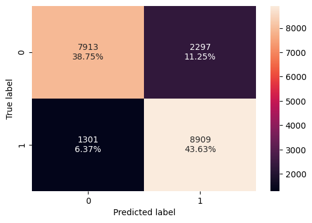

```python
confusion_matrix_sklearn(_tuned_ada, X_train_over, y_train_over)
```

#### Observations

- On training set, the model correctly predicted 82.38% of the cases. 8909 true positives were correctly predicted as true, and 7913 true negatives were predicted as negative.
- Of the 10,210 applications, 1,301 were predicted as negative but were positive (false negatives).
- Similarly, 2297 of the 10210 applications were predicted as true but were negative (false positives).

Validation set

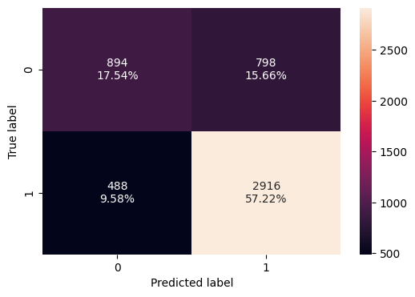

```python
confusion_matrix_sklearn(_tuned_ada, X_val, y_val)
```

#### Observations

- On validation set, the model correctly predicted 74.76% of the cases. 2916 true positives were correctly predicted as true, and 894 true negatives were predicted as negative.
- Of the 3,404 applications, 488 were predicted as negative but were positive (false negatives).
- Similarly, 798 of the 1692 applications were predicted as true but were negative (false positives).

### **Tuning Random forest using undersampled data**

- **RandomForestClassifier**
- **Hyperparameters** to consider:
  - "n_estimators": [50,100,150,200],
  - "max_depth": [10, 15, 20, None],
  - "min_samples_leaf": [10,15,25,30],
  - "max_features": ["sqrt", "log2"],
  - "max_samples": [0.3, 0.5, 0.7, 0.9],
  - "class_weight" : ['balanced', 'balanced_subsample'],
  - "criterion": ["gini", "entropy"]
- **Scorer**: f1_score
- **RandomizedSearchCV**
  - estimator: Random Forest
  - param_grid: Hyperparameters
  - jobs = -1
  - n_iter = 60
  - cv = 5
  - random state = 1

```python
# Best parameters
```

```
Best parameters are {'n_estimators': 50, 'min_samples_leaf': 15, 'max_samples': 0.7, 'max_features': 'log2', 'max_depth': 10, 'criterion': 'gini', 'class_weight': 'balanced_subsample'} with CV score=0.7163865276215198:
```

Fitting the model using the best hyperparameters combination identified

```python
_tuned_rf = RandomForestClassifier(
    random_state=1,
    n_estimators=50,
    max_depth=10,
    min_samples_leaf=15,
    max_samples=0.7,
    max_features='log2',
    criterion='gini',
    class_weight='balanced_subsample'
)

_tuned_rf.fit(X_train_un, y_train_un)
```

```
RandomForestClassifier(class_weight='balanced_subsample', max_depth=10,
                       max_features='log2', max_samples=0.7,
                       min_samples_leaf=15, n_estimators=50, random_state=1)
```

**Tuned Random Forest model using undersampled data - Results:**

Training set

```python
_tuned_rf_perf_train = model_performance_classification_sklearn(_tuned_rf, X_train_un, y_train_un)
_tuned_rf_perf_train
```

|  | Accuracy | Recall | Precision | F1 |
| --- | --- | --- | --- | --- |
| 0 | 0.720067 | 0.756597 | 0.705084 | 0.729933 |

Validation set

```python
_tuned_rf_perf_val = model_performance_classification_sklearn(_tuned_rf, X_val, y_val)
_tuned_rf_perf_val
```

|  | Accuracy | Recall | Precision | F1 |
| --- | --- | --- | --- | --- |
| 0 | 0.720369 | 0.737368 | 0.825386 | 0.778898 |

**Confusion Matrix**

Training set

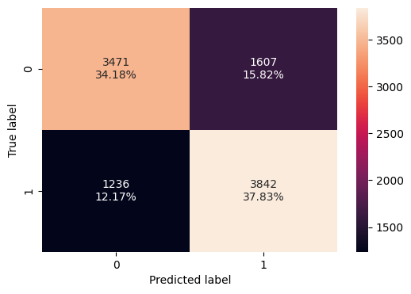

```python
confusion_matrix_sklearn(_tuned_rf, X_train_un, y_train_un)
```

#### Observations

- On training set, the model correctly predicted 72,01% of the cases. 3,842 true positives were correctly predicted as true, and 3471 true negatives were predicted as negative.
- Of the 5078 applications, 1236 were predicted as negative but were positive (false negatives).
- Similarly, 1607 of the 5078 applications were predicted as true but were negative (false positives).

Validation set

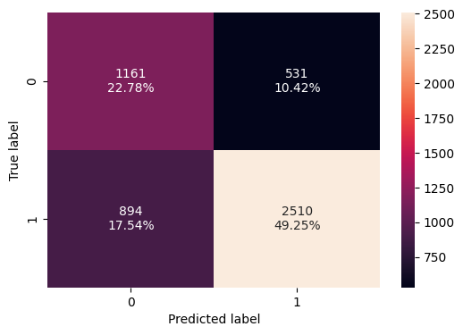

```python
confusion_matrix_sklearn(_tuned_rf, X_val, y_val)
```

#### Observations

- On validation set, the model correctly predicted 72.03% of the cases. 2510 true positives were correctly predicted as true, and 1161 true negatives were predicted as negative.
- Of 3,404 applications, 894 were predicted as negative but were positive (false negatives).
- Similarly, 531 of 1692 applications were predicted as true but were negative (false positives).

### **Tuning with Gradient boosting with oversampled data**

- **GradientBoostingClassifier**
- **Pipeline**
- **Hyperparameters** to consider:
  - init": _init_estimator,
  - n_estimators": [100, 150, 200, 250],
  - learning_rate": [0.01, 0.05, 0.1],
  - subsample":[0.5, 0.6, 0.7, 0.8, 1],
  - max_features":['sqrt', 'log2', None],
  - max_depth": [3, 5, 8, 10,],
  - min_samples_split": [6, 8, 10, 12],
  - min_samples_leaf": [4, 8,10],
- **Scorer**: f1_score
- **RandomizedSearchCV**
  - estimator: Random Forest
  - param_grid: Hyperparameters
  - jobs = -1
  - n_iter = 25
  - cv = 5
  - random state = 1

```python
print("Best parameters are {} with CV score={}:" .format(_gb_randomized_cv.best_params_,_gb_randomized_cv.best_score_))
```

```
Best parameters are {'subsample': 1, 'n_estimators': 100, 'min_samples_split': 10, 'min_samples_leaf': 10, 'max_features': 'log2', 'max_depth': 8, 'learning_rate': 0.05, 'init': AdaBoostClassifier(estimator=DecisionTreeClassifier(criterion='entropy',
                                                    max_depth=8,
                                                    min_samples_split=10,
                                                    random_state=1),
                   learning_rate=0.2, n_estimators=60, random_state=1)} with CV score=0.8153995965156124:
```

```python
_tuned_gb_rs = GradientBoostingClassifier(
    random_state=1,
    n_estimators=100,
    min_samples_split=13,
    min_samples_leaf=13,
    max_features='log2',
    max_depth=13,
    learning_rate=0.01,
    init= AdaBoostClassifier(estimator=DecisionTreeClassifier(criterion='entropy',
                                                    max_depth=8,
                                                    min_samples_split=10,
                                                    random_state=1),
                   learning_rate=0.05, n_estimators=60, random_state=1)
)
_tuned_gb_rs.fit(X_train_over, y_train_over)
```

```
GradientBoostingClassifier(init=AdaBoostClassifier(estimator=DecisionTreeClassifier(criterion='entropy',
                                                                                    max_depth=8,
                                                                                    min_samples_split=10,
                                                                                    random_state=1),
                                                   learning_rate=0.05,
                                                   n_estimators=60,
                                                   random_state=1),
                           learning_rate=0.01, max_depth=13,
                           max_features='log2', min_samples_leaf=13,
                           min_samples_split=13, random_state=1)
```

**Tuned GradientBoost model using oversampled data - Results:**

Training set

```python
_tuned_gb_perf_train = model_performance_classification_sklearn(_tuned_gb_rs, X_train_over, y_train_over)
_tuned_gb_perf_train
```

|  | Accuracy | Recall | Precision | F1 |
| --- | --- | --- | --- | --- |
| 0 | 0.825612 | 0.87238 | 0.797761 | 0.833404 |

Validation set

```python
_tuned_gb_perf_val = model_performance_classification_sklearn(_tuned_gb_rs, X_val, y_val)
_tuned_gb_perf_val
```

|  | Accuracy | Recall | Precision | F1 |
| --- | --- | --- | --- | --- |
| 0 | 0.74686 | 0.853114 | 0.78614 | 0.818259 |

**Confusion Matrix**

Training set

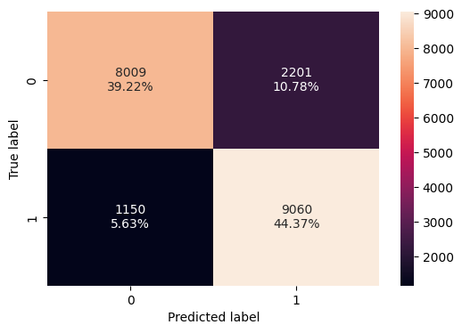

```python
confusion_matrix_sklearn(_tuned_gb_rs, X_train_over, y_train_over)
```

#### Observations

Validation set

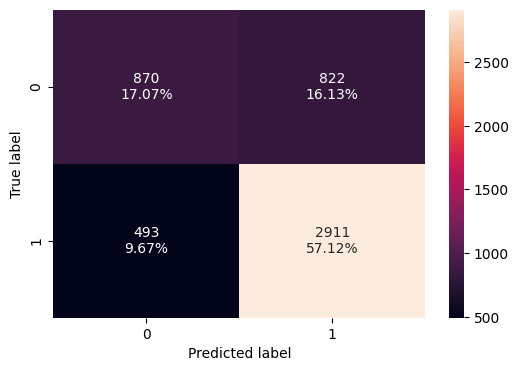

```python
confusion_matrix_sklearn(_tuned_gb_rs, X_val, y_val)
```

### **Tuning XGBoost using oversampled data**

- **XGBClassifier (random_state=1,eval_metric='logloss')**
- **Hyperparameters** to consider:
  - n_estimators':[100,150,200,350,500],
  - learning_rate':[0.005, 0.01,0.05,0.1,0.2,0.3],
  - gamma':[0,1,3,5,7],
  - subsample':[0.6,0.5,0.9],
  - max_depth':np.arange(1,15,2),
  - reg_lambda':[0.1,1,5,10,40],
  - reg_alpha':[0.1,1,5,10,40],
  - colsample_bytree':[0.5,0.7,1],
  - min_child_weight':[1,3,5,8]}
- **Scorer**: f1_score
- **RandomizedSearchCV**
  - estimator: Random Forest
  - param_grid: Hyperparameters
  - jobs = -1
  - n_iter = 60
  - cv = 5
  - random state = 1

```python
print("Best parameters are {} with CV score={}:" .format(_tuned_xgb.best_params_,_tuned_xgb.best_score_))
```

```
Best parameters are {'subsample': 0.9, 'reg_lambda': 1, 'reg_alpha': 1, 'n_estimators': 100, 'min_child_weight': 3, 'max_depth': np.int64(9), 'learning_rate': 0.01, 'gamma': 5, 'colsample_bytree': 0.5} with CV score=0.8211153123201177:
```

```python
_tuned_xgb = XGBClassifier(
    random_state=1,
    subsample=0.9,
    reg_lambda=1,
    reg_alpha=1,
    n_estimators=100,
    min_child_weight=3,
    max_depth=14,
    learning_rate=0.01,
    gamma=5,
    colsample_bytree=0.5
)

_tuned_xgb.fit(X_train_over, y_train_over)
```

```
XGBClassifier(base_score=None, booster=None, callbacks=None,
              colsample_bylevel=None, colsample_bynode=None,
              colsample_bytree=0.5, device=None, early_stopping_rounds=None,
              enable_categorical=False, eval_metric=None, feature_types=None,
              gamma=5, grow_policy=None, importance_type=None,
              interaction_constraints=None, learning_rate=0.01, max_bin=None,
              max_cat_threshold=None, max_cat_to_onehot=None,
              max_delta_step=None, max_depth=14, max_leaves=None,
              min_child_weight=3, missing=nan, monotone_constraints=None,
              multi_strategy=None, n_estimators=100, n_jobs=None,
              num_parallel_tree=None, random_state=1, ...)
```

**Tuned XGBoost using oversampled data - Results:**

Training set

```python
_tuned_xgb_perf_train = model_performance_classification_sklearn(_tuned_xgb, X_train_over, y_train_over)
_tuned_xgb_perf_train
```

|  | Accuracy | Recall | Precision | F1 |
| --- | --- | --- | --- | --- |
| 0 | 0.810578 | 0.898629 | 0.764074 | 0.825907 |

Validation set

```python
_tuned_xgb_perf_val = model_performance_classification_sklearn(_tuned_xgb, X_val, y_val)
_tuned_xgb_perf_val
```

|  | Accuracy | Recall | Precision | F1 |
| --- | --- | --- | --- | --- |
| 0 | 0.746468 | 0.896005 | 0.764794 | 0.825216 |

**Confusion Matrix**

Training set

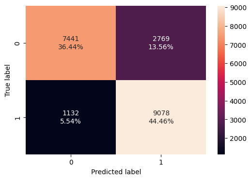

```python
confusion_matrix_sklearn(_tuned_xgb, X_train_over, y_train_over)
```

#### Observations

Validation set

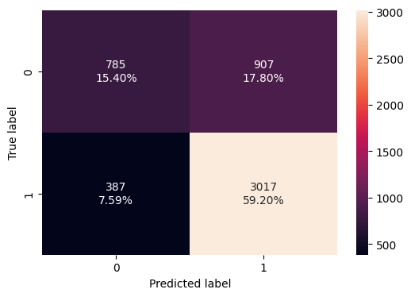

```python
confusion_matrix_sklearn(_tuned_xgb, X_val, y_val)
```

#### Observations

**We have now tuned all the models, let's compare the performance of all tuned models and see which one is the best.**

#### Observations:

- Boosting models trained on the oversampled data got better performance and generalization. Consequently, all three models were subjected to hyperparameter tuning.
- Furthermore, the Random Forest were also subjected to hyperparameter tuning in an attempt to identify hyperparameters that achieve better results.

**AdaBoost with over sampled data:**

- Compared to the model with no tuning, this model got a slightly better F1-Score, both on training and validation sets
  - Model's scores without tuning: 0.805449 on training - 0.809818 on validation)
  - Model's scores with tuning: 0.831995 on training - 0.819331 on validation)
- It is generalizing correctly.
- Recall on training set was 0.8725 on training set and 0.8566 on validation set. Precision score is low, but F1-score is good.

**Gradient boosting with oversampled data:**

- Compared to the model with no tuning, this model got a slightly better F1-Score, both on training and validation sets
  - Model's scores without tuning: 0.818541 on training - 0.817290 on validation)
  - Model's scores with tuning: 0.833404 on training - 0.818259 on validation)
- It is generalizing correctly.
- For this model, an AdaBoost classifier was utilized as the base estimator to generate initial predictions before the residual errors were adjusted by the boosting process. This approach enables the model to learn from the predictions generated by AdaBoost.

**XGBoost using oversampled data**

- Achieve similar results to the model with no tuning. The primary difference is a reduced difference between the training and validation F1-scores.
  - Model's scores without tuning: 0.875105 on training -0.812369 on validation)
  - Model's scores with tuning: 0.825907 on training - 0.825216 on validation)

## Model performance comparison and choosing the final model

**Performance comparison - Tuned models**

**Training sets**

```python
_performance_results_train = pd.concat([_tuned_ada_perf_train.T, _tuned_rf_perf_train.T, _tuned_gb_perf_train.T, _tuned_xgb_perf_train.T],axis=1,)
_performance_results_train.columns=['Model 1: AdaBoost', 'Model 2: Random Forest', 'Model 3: Gradient Boost', 'Model 4: XGBoost']
_performance_results_train
```

|  | Model 1: AdaBoost | Model 2: Random Forest | Model 3: Gradient Boost | Model 4: XGBoost |
| --- | --- | --- | --- | --- |
| Accuracy | 0.823800 | 0.720067 | 0.825612 | 0.810578 |
| Recall | 0.872576 | 0.756597 | 0.872380 | 0.898629 |
| Precision | 0.795021 | 0.705084 | 0.797761 | 0.764074 |
| F1 | 0.831995 | 0.729933 | 0.833404 | 0.825907 |

**Validation sets**

```python
_performance_results_val = pd.concat([_tuned_ada_perf_val.T, _tuned_rf_perf_val.T, _tuned_gb_perf_val.T, _tuned_xgb_perf_val.T],axis=1,)
_performance_results_val.columns=['Model 1: AdaBoost', 'Model 2: Random Forest', 'Model 3: Gradient Boost', 'Model 4: XGBoost']
_performance_results_val
```

|  | Model 1: AdaBoost | Model 2: Random Forest | Model 3: Gradient Boost | Model 4: XGBoost |
| --- | --- | --- | --- | --- |
| Accuracy | 0.747645 | 0.720369 | 0.746860 | 0.746468 |
| Recall | 0.856639 | 0.737368 | 0.853114 | 0.896005 |
| Precision | 0.785137 | 0.825386 | 0.786140 | 0.764794 |
| F1 | 0.819331 | 0.778898 | 0.818259 | 0.825216 |

```python
print("\nTraining and Validation Performance Difference: TUNED MODELS \n")
_f1_df = pd.DataFrame()
_f1_df['F1_Training'] = pd.DataFrame(_performance_results_train.iloc[3])
_f1_df['F1_Validation'] = pd.DataFrame(_performance_results_val.iloc[3])

_f1_df['Difference'] = _f1_df['F1_Training'] - _f1_df['F1_Validation']
_f1_df
```

```
Training and Validation Performance Difference: TUNED MODELS
```

|  | F1_Training | F1_Validation | Difference |
| --- | --- | --- | --- |
| Model 1: AdaBoost | 0.831995 | 0.819331 | 0.012663 |
| Model 2: Random Forest | 0.729933 | 0.778898 | -0.048966 |
| Model 3: Gradient Boost | 0.833404 | 0.818259 | 0.015145 |
| Model 4: XGBoost | 0.825907 | 0.825216 | 0.000690 |

#### Observations:

In consideration of the following premises:

- The primary objective of this case study is to minimize both the number of applicants with a high probability of visa approval being predicted as "denied", and to minimize the number of applicants with a low probability of being approved being predicted as good candidates ("certified") (with F1-Score serving as the principal due to its balanced assessment of these two scenarios).
- Random Forest exhibited the lowest F1-Score on the training set (0.729933) and the validation set (0.778898) compared to the other models.
- AdaBoost, Gradient Boost and XGBoost demonstrated better results on both the training set and validation sets relative to RandomForest. It can be affirmed that these models are generalizing well.
- The performance of these three models is similar to each other. The main difference is that XGBoost showed a smaller difference between the training and validation score (0.000690).
- XGBoost have the highest F1-Score observed on the validation set: 0.825216.
- The GradientBoost model achieved a recall of 0.853114 on the validation set. XGBoost achieved a higher score = 0.896005. There is a considerable difference between them
- The validation set precision for GradientBoost is 0.786140. And 0.764794 for XGBoost. The difference is not determining.

**Final decision:**

**Therefore, considering these factors, the XGBoost model with oversampled data is considered the optimal choice.**

### **Performance check on the test set**

```python
_tuned_gb_perf_test = model_performance_classification_sklearn(_tuned_xgb, X_test, y_test)
_tuned_gb_perf_test
```

|  | Accuracy | Recall | Precision | F1 |
| --- | --- | --- | --- | --- |
| 0 | 0.731162 | 0.888367 | 0.753363 | 0.815314 |

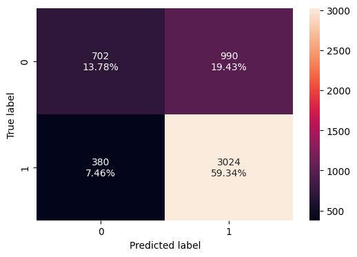

```python
confusion_matrix_sklearn(_tuned_xgb, X_test, y_test)
```

#### Observations

- On the testing set, the model was able to decrease the false negative rate to 7.46% (actual positive predicted as negative) and, the false positive rate to 19.43% (actual negatives predicted as positive).

```
Best precision:  0.7342983889796871
Best recall:  0.9239130434782609
Best threshold:  0.4716186
```

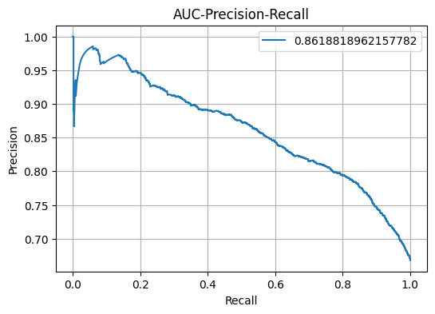

```python
# Case_status =  1 probabilities
_y_metrics_results = _tuned_xgb.predict_proba(X_test)[:, 1]

# get precision, recall and AUC-PR
_precision, _recall, _thresholds = precision_recall_curve(y_test, _y_metrics_results)
_auc_pr = auc(_recall, _precision)

_f1_scores = 2 * (_precision * _recall) / (_precision + _recall + 1e-10)
_best_index = np.argmax(_f1_scores)  # Index with higher F1-score

_best_precision = _precision[_best_index]
_best_recall = _recall[_best_index]
_best_threshold = _thresholds[_best_index]

print("Best precision: ", _best_precision)
print("Best recall: ", _best_recall)
print("Best threshold: ", _best_threshold)

# Plotting the curve
plt.figure(figsize=(6,4))
plt.plot(_recall, _precision,  label=_auc_pr)
plt.xlabel('Recall')
plt.ylabel('Precision')
plt.title('AUC-Precision-Recall')
plt.legend()
plt.grid()
plt.show()
```

#### Observations:

- An AUC-PR score close to 1 indicates that the model accurately classifies "Case_Status" = 1. Predicting positives with a low rate of false positives. AUC-PR score for this model was: 0.86.
- The best recall score at 0.47 threshold is 0.92, and 0.73 on precision.

#### Feature importance

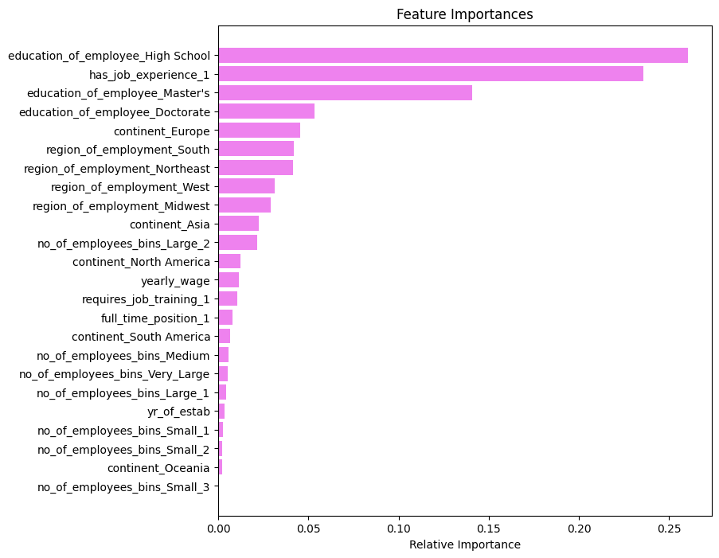

```python
_feature_names = X_train_over.columns
_importances = _tuned_xgb.feature_importances_
_index = np.argsort(_importances)

plt.figure(figsize=(8, 8))
plt.title("Feature Importances")
plt.barh(range(len(_index)), _importances[_index], color="violet", align="center")
plt.yticks(range(len(_index)), [_feature_names[i] for i in _index])
plt.xlabel("Relative Importance")
plt.show()
```

#### Observations

Feature importances which determine the profile of applicants whose visa will be approved or denied are related to:

- The applicant's academic level.
- Whether or not they have work experience.
- Their current continent of residence.
- The region where they would work if the visa is approved.

## Actionable Insights and Recommendations

**Key Takeaways - Shortlisting Candidates with Higher Chances of Visa Approval**

These attributes have a more significant impact if:

- Applicants possessing just a high school diploma have a higher rate of denials.
- Prior work experience benefits the applicant to get its visa approved (the approval rate for the 14,802 applicants with work experience is 74.47%. Whereas, the approval rate for those without prior experience is 56.13%)
- Master's Degree and Doctorate Degree holders exhibit a greater likelihood of approval (78.63% acceptance rate). Similarly, of the 2,192 Doctoral degree holders who applied, 1,912 were approved, representing an 87.23% acceptance rate, while the remaining 12.77% were denied.
- Applicants from Europe exhibit a greater likelihood of approval.
- Northeast, South and West regions exhibit high demand for foreign workers.

**Recommend a suitable profile for the applicants for whom the visa should be certified or denied based on the drivers that significantly influence the case status.**

**Strong profile for visa approval**

- Holds a university degree. Even stronger if possessing a Master's or Doctorate degree.
- Has work experience.
- Comes from a European country.
- The intented work region is: Northeast, South, or West.

**Weak Profile for Visa Approval**

- Possesses only a high school diploma.
- Has no work experience.
- Comes from a South American country.